# Car Selling Prices

1/20/2023

[figure not shown]

## Selling Price of a Ford Explorer

```
       fit      lwr      upr
1 13124.51 8454.656 20373.71
```

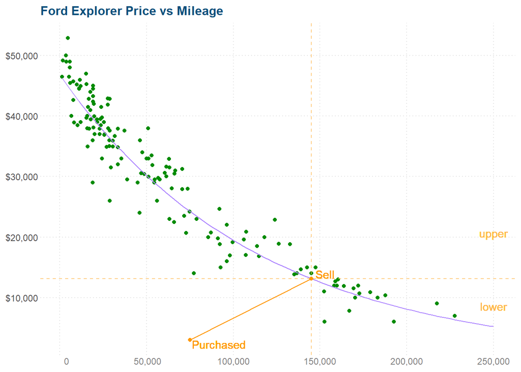

```r
library(tidyverse)
library(ggplot2)
library(DT)
library(car)
library(pander)
car_dat <- read.csv("03_CarPricesTrue.csv")

# aesthetics
#palette(c("#ffc6c6", "#eeaa88", "#eec290", "grey", "#afc9c6", "#468499"))


my_theme <-
  theme(legend.key = element_rect(colour = NA, fill = NA),
          panel.background = element_blank(),
          plot.background = element_blank(),
          panel.grid.major.y = element_line(color = "grey88",
                                            linetype = "dotted"),
          panel.grid.major.x = element_line(color = "grey88",
                                            linetype = "dotted"),
          plot.title = element_text(color = "#0C4F7B",
                                    size = 12,
                                    face = "bold"),
          plot.caption = element_text(color = "gray50",
                                      face = "italic",
                                      size = 6,
                                      hjust = 0.5),
          axis.ticks = element_blank(),
          axis.title = element_blank(),
          axis.text.x = element_text(color = "gray50"))

# regression values
lm.log <- lm(log(price) ~ mileage, data=car_dat)
b.log <- coef(lm.log)
price.preds <- exp(predict(lm.log, data.frame(mileage=145000), interval="predict"))
price.preds
mycar <- "#ff9900"
intvl <- "#ffb84d"
dots <- "green4"
logline <- "mediumpurple1"

# plotted regression
car_plot <- ggplot(car_dat, aes(y=price, x=mileage)) +
  geom_point(color=dots, pch=16) +
  geom_point(aes(x=75000,y=3000), color=mycar) +
  geom_text(x=91900, y=2300, label = "Purchased", color=mycar) +
  labs(title="Ford Explorer Price vs Mileage", x="Mileage", y="Price (USD)") +
  scale_y_continuous(labels = scales::dollar_format()) +
  scale_x_continuous(labels = function(x) format(x, big.mark = ",")) +
  theme(legend.position = "none") +
  my_theme

car_plot_final <- car_plot +
  stat_function(fun=function(x) exp(b.log[1] + b.log[2]*x), aes(color="log(Y)")) +
  geom_hline(yintercept=price.preds,  alpha=0.7, lty=2, color=intvl) +
  geom_vline(xintercept=145000,  alpha=0.7, lty=2, color=intvl) +
  geom_text(aes(x=250000, y=price.preds[2]+100),
            label="lower",
            color=intvl) + # color appeared dark so chose a lighter one
  geom_text(aes(x=250000, y=price.preds[3]+300),
            label="upper",
            color=intvl) + # color appeared dark so chose a lighter one
  geom_text(x=153000, y=13900, label = "Sell", color=mycar) +
  geom_point(aes(x=145000,y=price.preds[1]), color=mycar) +
  geom_segment(x=75000, xend=145000, y=3000, yend=price.preds[1], color=mycar) +
  scale_color_manual(values = logline)
car_plot_final

costpm <- (price.preds[1]-3000)/(14500-7500)
```

## Technical Details

### Linear Regression

We fit a linear regression model to the car data.

$$\underbrace{Y_i}_\text{Price} = \overbrace{\beta_0}^\text{y-int} +
\overbrace{\beta_1}^\text{slope} \underbrace{X_i}_\text{Mileage} +
\epsilon_i \quad \text{where} \ \epsilon_i \sim N(0, \sigma^2)$$

#### Hypothesis

The null hypothesis for the analysis is that the slope is zero; there is not a linear relationship between the mileage and the price of Ford Explorers. The alternative hypothesis is that slope is not zero; there is in a linear relationship between the mileage and the price. The level of significance for our purposes is 0.05.

$$H_0: \beta_1 = 0$$

$$H_a: \beta_1 \neq 0$$

$$\alpha = 0.05$$

#### Regression Plot

We plot a linear regression on the price versus mileage.

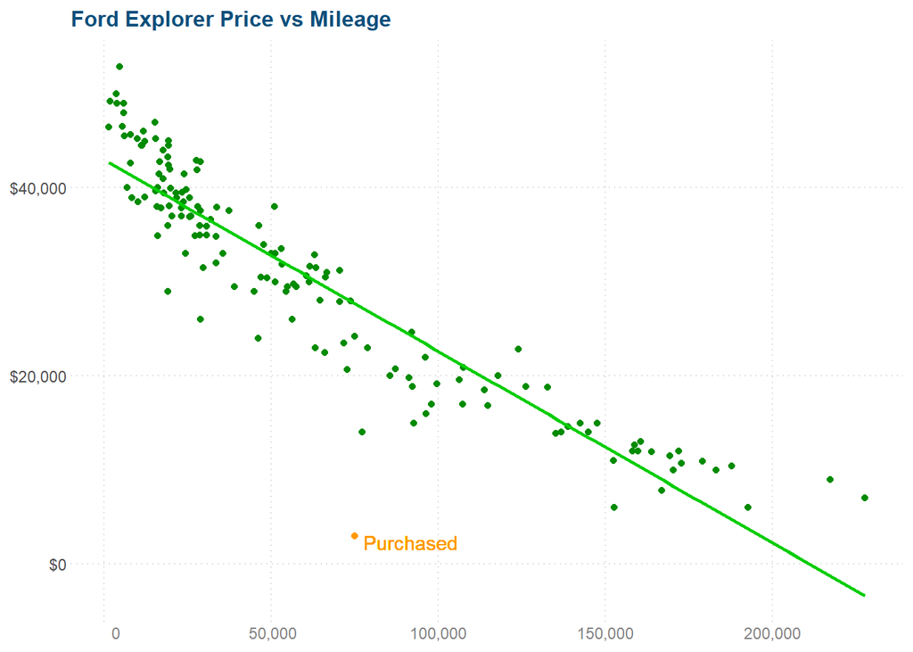

#### Regression Results

Below is a summary of the results.

```r
# regression summary
pander(car.sum <- summary(car.lm))
```

|  | Estimate | Std. Error | t value | Pr(>\|t\|) |
| --- | --- | --- | --- | --- |
| **(Intercept)** | 42975 | 570.7 | 75.3 | 3.067e-122 |
| **mileage** | -0.2036 | 0.006855 | -29.7 | 3.578e-65 |

Fitting linear model: price ~ mileage

| Observations | Residual Std. Error | $R^2$ | Adjusted $R^2$ |
| --- | --- | --- | --- |
| 154 | 4648 | 0.853 | 0.8521 |

$$\underbrace{\hat{Y}_i}_\text{Mean Price} = \overbrace{ \$
42,975.18}^\text{est. y-int} - \overbrace{0.20 }^\text{est. slope}*
\underbrace{X_i}_\text{Mileage}$$

#### Regression Assumptions

We examine the assumptions.

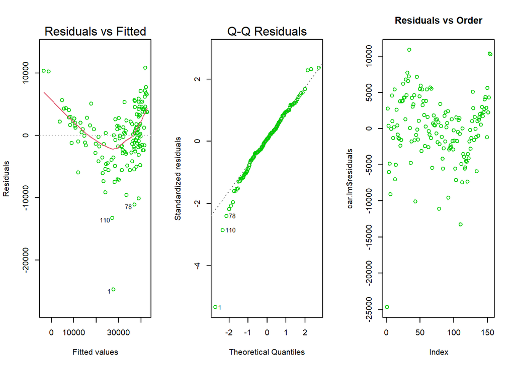

```r
par(mfrow=c(1,3))
plot(car.lm, which = 1:2, col="green3")
plot(car.lm$residuals, main="Residuals vs Order", col="green3")
```

The residuals vs fitted plot shows issues with both the linearity and the variance, while the residuals vs Order indicates there may be issues with the independence of the error terms.

### Y Transformations

We will compare different transformations to see whether we can improve the outcome.

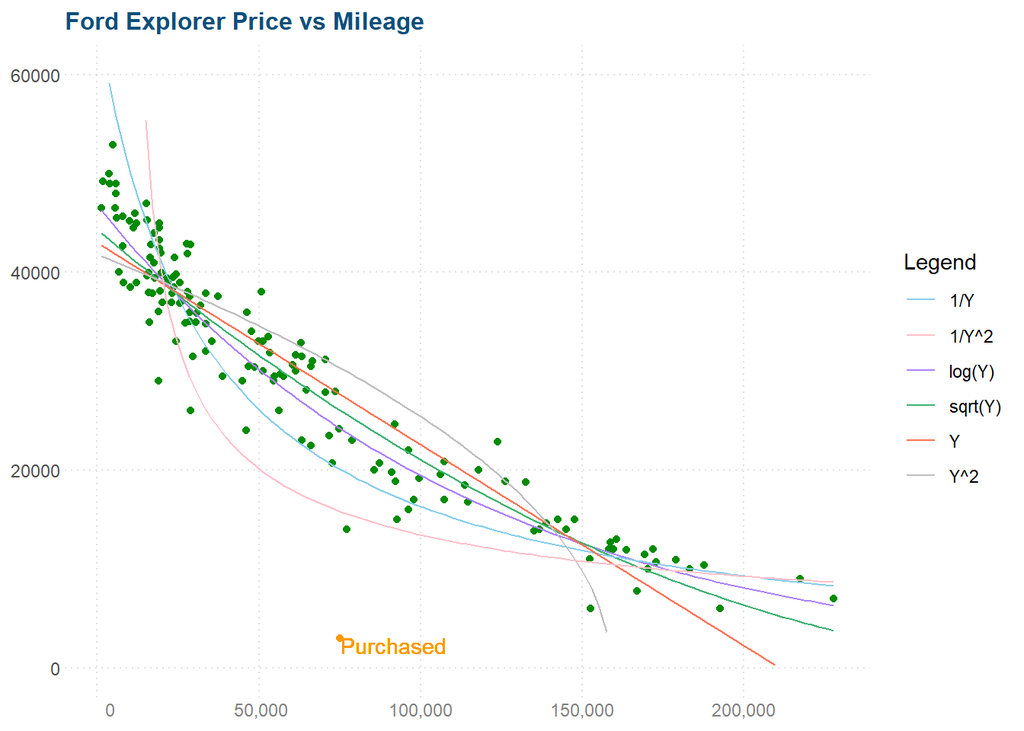

```r
# lm.log <- lm(log(price) ~ mileage, data=car_dat)
# b.log <- coef(lm.log)

lm.sqrt <- lm(sqrt(price) ~ mileage, data=car_dat)
b.sqrt <- coef(lm.sqrt)

lm.1oY <- lm(1/(price) ~ mileage, data=car_dat)
b.1oY <- coef(lm.1oY)


b.y <- coef(car.lm)

lm.y2 <- lm((price^2) ~ mileage, data=car_dat)
b.y2 <- coef(lm.y2)

lm.1oY2 <- lm(1/(price^2) ~ mileage, data=car_dat)
b.1oY2 <- coef(lm.1oY2)


# transformations plot
car_plot +
  scale_y_continuous(limits=c(0,60000)) +
  scale_x_continuous(labels = function(x) format(x, big.mark = ",")) +
    ylim(0,60000) +
  stat_function(fun=function(x) exp(b.log[1] + b.log[2]*x), aes(color="log(Y)")) +
  stat_function(fun=function(x) (b.sqrt[1] + b.sqrt[2]*x)^2, aes(color="sqrt(Y)")) +
  stat_function(fun=function(x) 1/(b.1oY[1] + b.1oY[2]*x), aes(color="1/Y")) +
  stat_function(fun=function(x) b.y[1] + b.y[2]*x, aes(color="Y")) +
  stat_function(fun=function(x) sqrt(b.y2[1] + b.y2[2]*x), aes(color="Y^2")) +
  stat_function(fun=function(x) 1/sqrt(b.1oY2[1] + b.1oY2[2]*x), aes(color="1/Y^2")) +
  scale_colour_manual("Legend", values = c("Skyblue", "Pink", "mediumpurple1", "mediumseagreen", "coral1", "grey")) +
  theme(legend.position = "right")
```

#### BoxCox

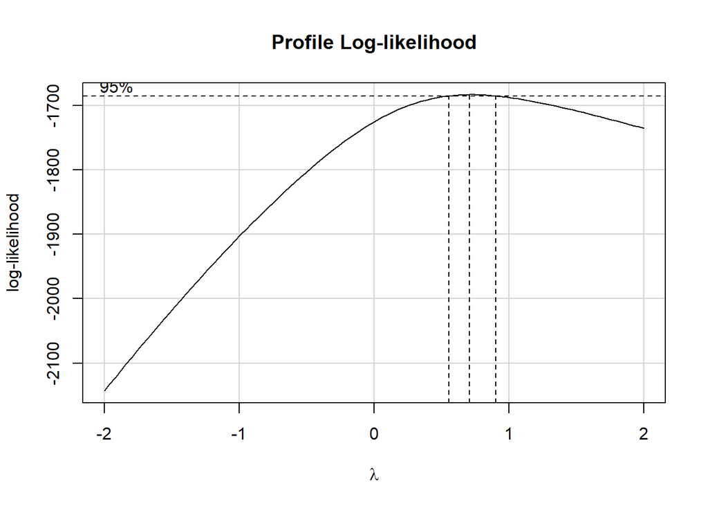

```r
boxCox(lm(price~mileage, data=car_dat))
```

When we run the Box Cox test, the center line suggests a $\lambda$ of 0.75. However, this isn’t easily intepretable, so we will examine $\lambda$ values of 0.5 and 0.

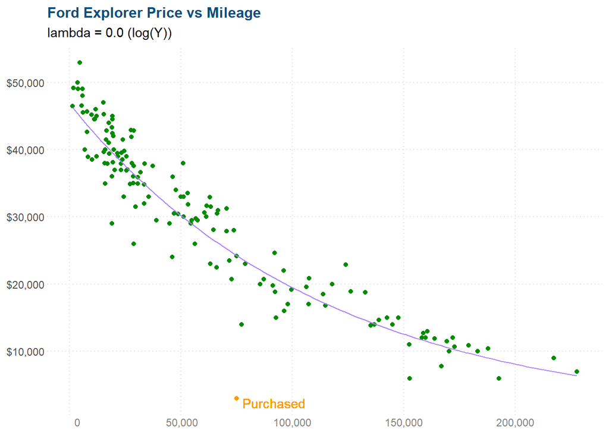

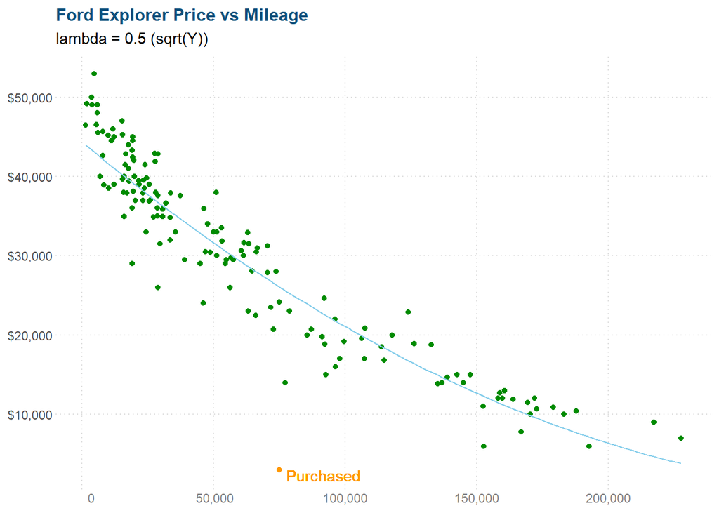

```r
car_plot +
  stat_function(fun=function(x) exp(b.log[1] + b.log[2]*x), aes(color="log(Y)")) +
  scale_color_manual(values = logline) +
  theme(legend.position = "none") +
  labs(subtitle = "lambda = 0.0 (log(Y))")

car_plot +
   stat_function(fun=function(x) (b.sqrt[1] + b.sqrt[2]*x)^2, aes(color="sqrt(Y)")) +
  scale_color_manual(values = "skyblue") +
  theme(legend.position = "none") +
  labs(subtitle = "lambda = 0.5 (sqrt(Y))")
```

Eventhough, the square root transformation version was closer to the Box Cox value selected by the function, the log version looks like it fits the data slightly better.

#### Assumptions

The assumptions for the log transformation plot look better (below left), as the square root plot is having more difficulty with linearity.

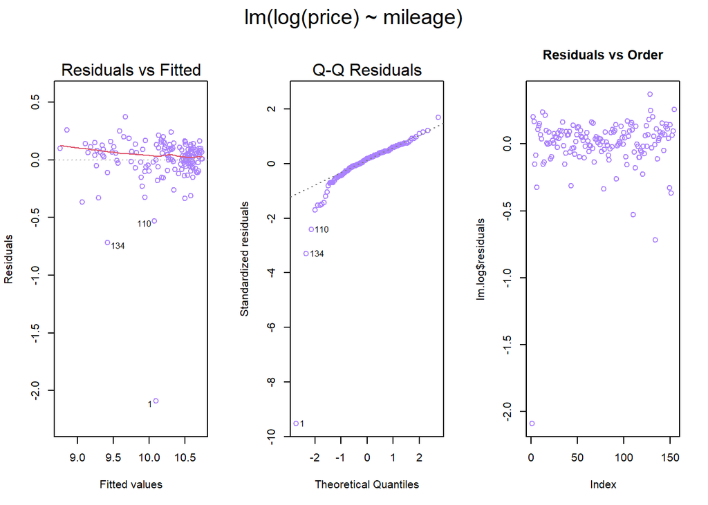

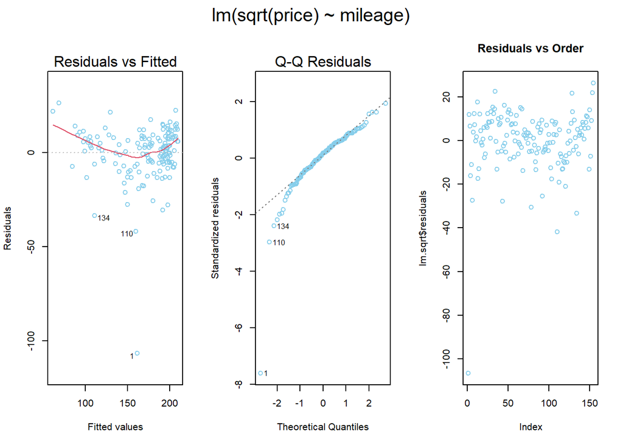

```r
par(mfrow=c(1,3), oma=c(0,0,2,0))
plot(lm.log, which = 1:2, col="mediumpurple1")
plot(lm.log$residuals, main="Residuals vs Order", col=logline)

par(mfrow=c(1,3), oma=c(0,0,2,0))
plot(lm.sqrt, which = 1:2, col="skyblue")
plot(lm.sqrt$residuals, main="Residuals vs Order", col="skyblue")
```

### Prediction

We predict the price of the vehicle at 145,000 miles to be around $13,000 with a lower bound of $8,455 and an upper bound of $20,374.

```r
# The call to predict is above in the code block for the first graph.
pander(price.preds)
```

| fit | lwr | upr |
| --- | --- | --- |
| 13125 | 8455 | 20374 |